# ELE618 - Sistemas Elétricos Industriais

Instalações Elétricas - Ademaro A. M. B. Cotrim  
Cap16 - Ademaro A. M. B. Cotrim

Prof. Dr. Thales A. C. Maia

UFMG - DEE

# 16.1 Fundamentos

## Radiação e Espectro Visível

- Radiação é a emissão ou transporte de energia sob a forma de ondas eletromagnéticas.
- A velocidade de propagação depende do meio, sendo dada por $c = \lambda \cdot f$.
- O espectro visível situa-se geralmente entre 380 nm e 780 nm, dividindo-se em cores:
  - 380 a 436 nm: violeta;
  - 436 a 495 nm: azul;
  - 495 a 566 nm: verde;
  - 566 a 589 nm: amarelo;
  - 589 a 627 nm: laranja;
  - 627 a 780 nm: vermelho.
- Radiações imediatamente fora dessa faixa são chamadas ultravioleta (100 a 400 nm) e infravermelha (780 a 1.000 nm).

## Fluxo e Eficácia Luminosa

- **Fluxo luminoso ($\Phi$):** Grandeza derivada do fluxo radiante, avaliada pela ação sobre um receptor seletivo (olho humano). Medido em lumens (lm).
- Um lúmen corresponde à luz produzida em 1s por uma radiação com $\lambda = 555$ nm e fluxo radiante de 1/680 W.
- **Eficácia luminosa:** Razão do fluxo luminoso para o fluxo radiante correspondente.
- A eficiência para lâmpadas (elétricas) é a razão do fluxo produzido para a potência elétrica consumida (lm/W).

## Intensidade Luminosa e Iluminância

- **Intensidade luminosa ($I$):** Limite da razão do fluxo luminoso em um ângulo sólido. Medida em candelas (cd).
- Uma candela corresponde à intensidade de uma fonte que emite 12,56 lm em todas as direções.
- **Iluminância ($E$):** Razão do fluxo luminoso recebido por uma superfície para a área dessa superfície. Medida em lux (lx, 1 lm/m²).
- **Iluminância média ($E_m$):** Definida no plano de trabalho imaginário (0,75 a 1 m do piso). Calculada por $E_m = \Phi_T \cdot \mu \cdot d / S$.

A Figura 16.1 ilustra a intensidade luminosa e a iluminância, mostrando a relação entre o fluxo luminoso em um ângulo sólido e a incidência sobre uma superfície.

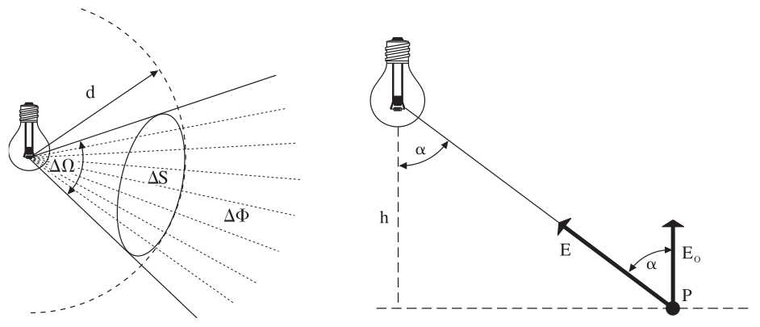

Fig. 1: Intensidade luminosa e iluminância (Cotrim, 2009)

## Luminárias e Fator de Utilização

- **Luminária:** Aparelho que distribui, direciona e converte luz.
- Requisitos básicos:
  - Suporte elétrico, controle do fluxo e manutenção térmica.
  - Facilidade de manutenção e adequação ao ambiente.
- **Fator de utilização ($\mu$):** Razão do fluxo útil para o fluxo total emitido.
  - Depende da distribuição de luz, rendimento, reflexões (teto/paredes) e índice do local ($K$).

# 16.2 Tipos de lâmpadas

## Lâmpadas incandescentes

- Partes principais: filamento, bulbo, gás e base.
- Filamento de tungstênio espiralado (reduz perda de calor) operando em alta temperatura.
- Uso de gás inerte (nitrogênio, argônio, criptônio) para reduzir evaporação.
- **Lâmpadas halógenas:** Adição de halogênio cria um ciclo regenerativo que evita o escurecimento do bulbo.
- **Lâmpadas com refletor dicróico:** Refletem a luz visível e transmitem o calor (infravermelho) para trás.

## Lâmpadas de descarga

- Luz produzida por descarga elétrica em gás ou vapor ionizado.
- Podem usar substâncias luminescentes ativadas por radiação UV.
- Exigem reator (limitar corrente) e starter/ignitor (iniciar descarga).
- Ignição seguida de estabilização do gás/vapor.
- **Lâmpadas fluorescentes tubulares:** Descarga de baixa pressão, radiação UV convertida em luz por pó fluorescente.
- **Lâmpadas fluorescentes compactas:** Menor tamanho, mantendo as características de eficiência.

## Lâmpadas a vapor de mercúrio e metálico

- **Vapor de mercúrio:** Aparência branco-azulada, descarga em alta pressão. Uso de camada de fósforo para melhorar a reprodução de cor, convertendo UV em vermelho.
- **Vapor metálico:** Similares às de mercúrio, porém com aditivos (iodeto, índio, tálio, sódio) que melhoram a eficácia e a reprodução de cor. Comuns na iluminação de grandes áreas.

## Lâmpadas de luz mista e sódio

- **Luz mista:** Tubo de descarga em série com um filamento de tungstênio (que atua como reator limitador).
  - Combina radiação convertida pelo pó, luz da descarga e luz quente do filamento.
- **Vapor de sódio de alta pressão:** Tubo com excesso de sódio e descarga estabilizada.
  - Elevada eficiência luminosa (até 150 lm/W) e temperatura de cor quente (~2.100 K). Muito usada em iluminação externa.

## LED (Light Emitting Diode)

- Diodo semicondutor que emite luz visível por **eletroluminescência**.
- Ocorre devido à recombinação de lacunas e elétrons na junção P-N, liberando energia na forma de fótons.
- As impurezas semicondutoras definem a faixa de energia e, portanto, a cor emitida.
- Vantagens incluem longa vida útil, alta eficiência e dimensões reduzidas.

# Exercícios

## Exercícios - Parte 1

1. Quais são as faixas de comprimento de onda do espectro visível?
2. Defina fluxo luminoso ($\Phi$).
3. Quais são os requisitos básicos de uma luminária?
4. Que parâmetros afetam o fator de utilização de uma luminária?
5. Qual é o princípio de funcionamento de uma lâmpada incandescente?

## Exercícios - Parte 2

6. Qual é o princípio de funcionamento de uma lâmpada de descarga de gases?
7. Quais são os componentes de uma lâmpada de luz mista?
8. Qual é o princípio de emissão de luz do LED?
9. Quais são as principais vantagens do LED sobre as lâmpadas incandescentes?
10. Que roteiro deve ser seguido nos cálculos de iluminação interna?

# Obrigado!

http://thalesmaia.com/